# R_Naive Bayes

Jang, Eunhee

2018년 5월 29일

### 목차

1. 확률에 대한 기본적인 이해
2. 나이브 베이즈 알고리즘
3. 나이브 베이즈 실습
- 독버섯과 정상버섯의 분류
- 스팸메일과 햄메일의 분류
4. 머신러닝 자동화 스크립트에 나이브 베이즈 추가.

### [1. 나이브베이즈 이해](https://www.slideshare.net/oracleyu23/ss-97742019)

> 베이지안 기법 기반의 분류기는 훈련데이터를 활용해 특징 값이 제공하는 증거 기반으로 결과가 관측될 확률을 계산한다. 나중에 분류기가 레이블이 없는 데이터에 적용될 때 결과가 관측될 확률을 이용해서 새로운 특징에 가장 유력한 클리스를 예측한다.

### 2. 나이브 베이즈에 의한 분류

> 베이지안 분류기는 결과에 대한 전체 확률을 추정하기 위해 동시에 여러 속성 정보를 고려해야만 하는 문제에 가장 적합하다.

> 베이지안 확률의 이론은 사건에 대한 우도는 복수시행에서 즉시 이용할 수 있는 증거를 기반으로 추정해야만 한다는 아이디어에 뿌리를 두고 있다.

> 모든 사건이 독립이라면 다른 사건을 관측해 어떤 사건을 예측하는 것은 불가능 하다. 달리말해, 종속사건이 예측모델링에 기반이 된다.

#### 스팸메일과 햄메일을 정확하게 구분하기 위해서는?

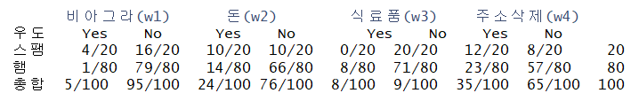

비아그라 단어 하나만 가지고 스팸메일인지 분류하려면 처방전도 스팸이 될 확률이 높아지니 다른 단어들도 같이 포함시켜서 확률을 구해야한다.

예: 비아그라 = yes, 돈 = no, 식료품 = no, 주소삭제 = yes 용어: ￢: 존재하지 않는다(부정) ㅋ : 존재한다(긍정)

#### 예제: 비아그라와 주소삭제는 포함하고 돈과 식료품은 포함하지 않는 메세지가 스팸일 확률은 어떻게 되는가?

P(스팸|비아그라 ∩ ￢돈 ∩ ￢식료품 ∩ 주소삭제) = ?

P(A|B) = P(A ∩ B) / P(B) = P(B|A) * P(A) / P(B)

P(스팸|비아그라 ∩ ￢돈 ∩ ￢식료품 ∩ 주소삭제) = P(비아그라 ∩ ￢돈 ∩ ￢식료품 ∩ 주소삭제|스팸) * P(스팸) / P(비아그라 ∩ ￢돈 ∩ ￢식료품 ∩ 주소삭제) = P(비아그라|스팸) ∩ (￢돈|스팸) ∩ (￢식료품|스팸) ∩ (주소삭제|스팸) * P(스팸) / P(비아그라 ∩ ￢돈 ∩ ￢식료품 ∩ 주소삭제)

```r
# 우도란?
# 나타난 결과에 따라 여러 가능한 가설들을 평가할 수 있는 측도(Measure)임
# 우도는, 확률로 표현되나 각 가설에 대한 가능도/지지도 등의 의미가 강함
# 관측결과를 초래한 미지의 모수를 추정하는 것에 대한 함수적 표현임
# 연속사건에서는 특정 사건이 일어날 확률이 전부 0으로 계산되기 때문에 사건들이 일어날 가능성을 비교하는 것이 불가능하며, 가능도(우도)라는 개념을 적용해야 이를 비교할 수 있다.
# 셀 수 있는 사건에서는 확률과 가능도가 같다.

# 스팸일 우도 = P(비아그라|스팸) ∩ (￢돈|스팸) ∩ (￢식료품|스팸) ∩ (주소삭제|스팸) * P(스팸)
x <- (4/20) * (10/20) * (20/20) * (12/20) * (20/100)

# 햄일 우도?
y <- (1/80) * (66/80) * (71/80) * (23/80) * (80/100)

# 스팸일 확률
round(x / (x + y),2)
```

```
## [1] 0.85
```

> 독립적인 사건이 아닌 종속 사건의 경우 중첩된 정도가 항상 존재 -> 우도를 사용하여 전체를 구함

#### 문제265. 아래의 메일의 메세지를 보고 비아그라와 쿠폰이라는 메세지가 메일에 포함되어져 있으면 스팸일 확률이 어떻게 되는지 확인하시오

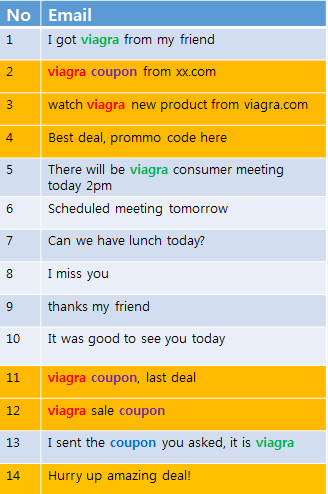

```r
cate <- rbind("spam","ham","total")

via <- data.frame( yes =c(4,3,sum(4,3)), no = c(2,5, sum(2,5)))
via_total <- rbind(sum(via[1,]), sum(via[2,]), sum(via[3,]))
via_spam <- cbind( via = cate,via,total = via_total)

coupon <- data.frame( yes =c(3,1, sum(3,1)), no = c(3,7,sum(3,7)))
coupon_total <- rbind(sum(coupon[1,]), sum(coupon[2,]), sum(coupon[3,]))
coupon_spam <- cbind(coupon = cate,coupon, total = coupon_total)

via_spam
```

```
##     via yes no total
## 1  spam   4  2     6
## 2   ham   3  5     8
## 3 total   7  7    14
```

```r
coupon_spam
```

```
##   coupon yes no total
## 1   spam   3  3     6
## 2    ham   1  7     8
## 3  total   4 10    14
```

```r
#스팸일 우도: P(스팸|비아그라 ∩ 쿠폰) = P(비아그라|스팸)∩ P(쿠폰|스팸) * p(스팸) / p(비아그라∩쿠폰)
x <-   (4 / 6) * (3/6) * (6/14)

x2 <- (via_spam[1,2] / via_spam[1,4]) * (coupon_spam[1,2] / coupon_spam[1,4]) * (via_spam[1,4] / via_spam[3,4])

# 햄일 우도: P(햄|비아그라 ∩ 쿠폰) = P(비아그라|햄)∩ P(쿠폰|햄) * p(햄)
y <- (3/8) * (1/8) * (8/14)
y
```

```
## [1] 0.02678571
```

```r
y2 <-  (via_spam[2,2] / via_spam[2,4]) * (coupon_spam[2,2] / coupon_spam[2,4]) * (via_spam[2,4] / via_spam[3,4])


round(x / (x + y), 2)
```

```
## [1] 0.84
```

```r
round(y2 / (x2 + y2), 2)
```

```
## [1] 0.16
```

### 3. 나이브베이즈 실습: 영화 장르(movie.csv) 선호도 분석

```r
# 1. data 로드
movie <- read.csv("C:/data/movie.csv", header = T)
head(movie)
```

```
##   나이 성별        직업 결혼여부 이성친구   장르
## 1 20대   여    디자이너       NO      YES 로맨틱
## 2 40대   남 홍보/마케팅       NO       NO   공포
## 3 10대   여 홍보/마케팅       NO      YES 로맨틱
## 4 20대   여    디자이너      YES       NO 로맨틱
## 5 10대   남        학생       NO       NO   액션
## 6 40대   남      자영업       NO       NO   공포
```

```r
# 2. data 정제
colnames(movie) <- c("age","gender","job","marry","friend","m_type")
attach(movie)
# movie[m_type == "SF",]

# 3. 영화장르
# unique(movie$m_type)
# length(unique(movie$m_type))

# 4. 30대이고 job이 IT인 기혼인 여자가 SF영화를 선택할 확률
# movie[m_type == "SF",]
# movie[movie$age == '30대' & movie$gender == '여' & movie$job == 'IT' & movie$marry == 'YES',]

# P(SF|30대 ∩ 여 ∩ IT ∩ YES)
# 공포우도 <- p(SF|"30대") * P(SF|"여") * P(SF|"IT") * P(SF|"YES")

# 5. 나이브 베이즈 함수를 이용하여
# install.packages("e1071")
library(e1071)
                    # training data , training label
                    # laplace : 확률이 0이 되지 않기위해 체인곱에서 0 을 제외하도록 대체할 수 있는 작은 수를 만든다
model <- naiveBayes(movie[1:5], movie$m_type, laplace = 1)
# model
                  # model , test data
result <- predict(model, movie[1:5])
# result

library(data.table)
# data.table(movie$m_type, result)
prop.table(table(ifelse(movie$m_type==result,"o","x" )))
```

```
##
##          o          x
## 0.97435897 0.02564103
```

```r
# 6. test data와 training data 나누기
library(e1071)

train_data <- movie[1:nrow(movie)-1, ]
test_data <- movie[nrow(movie), ]

ncol <- which(colnames(train_data) == 'm_type')
                    # training data , training label
model <- naiveBayes(train_data[,-ncol], train_data$m_type, laplace = 0)

                  # model , test data
result <- predict(model, test_data[,-ncol])
result == test_data[,'m_type']
```

```
## [1] TRUE
```

#### 4. 나이브베이즈 실습 : 독버섯과 정상버섯 분류 테스트

```r
# 1. 데이터 R로 로드
mushroom <- read.csv("C:/data/mushroom.csv", header = F, stringsAsFactors = F)

# 2. ? 와 '' 비어있는 데이터를 NA로 변경한다.
# View(mushroom)
mushroom[which(mushroom$V12 == '?'), 12] <- NA

for (i in (15:23)) {
  mushroom[which(mushroom[,i] == ''), i] <- NA
}

# 3. factor로 변환한다.

dim(mushroom)
```

```
## [1] 5343   23
```

```r
for (i in 1:23) {
  mushroom[,i] <- factor(mushroom[,i])
}

# str(mushroom)

# 4. 훈련데이터와 테스트 데이터로 나눈다.

set.seed(1)

# 행의 건수 확인
train_cnt <- round(0.75 * dim(mushroom)[1])
# shuffle 하는 방법 중 하나
train_indx <- sample(1:dim(mushroom)[1], train_cnt, replace = F)

mushroom_train <- mushroom[train_indx,]
mushroom_test <- mushroom[-train_indx,]

# 5. 나이브 베이즈 함수를 이용해서 독버섯과 일반 버섯을 분류하는 모델을 생성한다.

library(e1071)
# V1~: label(기준으로 사용), laplace: positive double controlling Laplace smoothing.
model1 <- naiveBayes(V1~. , data = mushroom_train, laplace = 0.0001)

# 6. 모델로 테스트 데이터로 정확도 측성한다.

result1 <- predict(model1,mushroom_test[, -1])
# head(result1)

# 7. 이원 교차표로 분류의 최종 결과를 확인한다.
library(gmodels)

CrossTable(x = mushroom_test[,1], y = result1)
```

```
##
##
##    Cell Contents
## |-------------------------|
## |                       N |
## | Chi-square contribution |
## |           N / Row Total |
## |           N / Col Total |
## |         N / Table Total |
## |-------------------------|
##
##
## Total Observations in Table:  1336
##
##
##                    | result1
## mushroom_test[, 1] |         e |         p | Row Total |
## -------------------|-----------|-----------|-----------|
##                  e |       876 |         0 |       876 |
##                    |   155.791 |   299.650 |           |
##                    |     1.000 |     0.000 |     0.656 |
##                    |     0.997 |     0.000 |           |
##                    |     0.656 |     0.000 |           |
## -------------------|-----------|-----------|-----------|
##                  p |         3 |       457 |       460 |
##                    |   296.679 |   570.637 |           |
##                    |     0.007 |     0.993 |     0.344 |
##                    |     0.003 |     1.000 |           |
##                    |     0.002 |     0.342 |           |
## -------------------|-----------|-----------|-----------|
##       Column Total |       879 |       457 |      1336 |
##                    |     0.658 |     0.342 |           |
## -------------------|-----------|-----------|-----------|
##
##
```

```r
          # 실제              예측
```

#### 문제267. NaiveBayes function을 생성하시오

```r
naive_bayes_fun <- function() {
  rm()
  setwd("C:/data")

  data<-file.choose("분석할 csv파일명을 입력하세요")

  na.string <- NA

  table1 <- read.csv(data, stringsAsFactors = F, header = F, na.string = na.string)

  col <- menu(colnames(table1), title = "라벨이 될 컬럼 이름을 입력하세요 ")

  col1 <- menu(colnames(table1), title = "수정할 컬럼 이름을 입력하세요 ")

  ch1 <- readline(prompt = "제거할 문자를 입력하세요 ")

  lap <- readline(prompt = "laplace값을 입력하세요 ")

  # data 정제

  table1[which(table1[,col1] == ch1), nrow(table)] <- NA

  # 3. factor로 변환한다.

  for (i in 1:dim(table1)[2]) {
    table1[,i] <- factor(table1[,i])
  }

  # 4. 훈련데이터와 테스트 데이터로 나눈다.

  set.seed(1)

  # 행의 건수 확인
  train_cnt <- round(0.75 * dim(table1)[1])
  # shuffle 하는 방법 중 하나
  train_indx <- sample(1:dim(table1)[1], train_cnt, replace = F)

  table_train <- table1[train_indx,]
  table_test <- table1[-train_indx,]

  # 5. 나이브 베이즈 함수를 이용해서 독버섯과 일반 버섯을 분류하는 모델을 생성한다.

  library(e1071)
  # V1~: label(기준으로 사용), laplace: positive double controlling Laplace smoothing.

  model1 <- naiveBayes(table_train[,col]~. , data = table_train, laplace = as.numeric(lap))
  model1

  # 6. 모델로 테스트 데이터로 정확도 측성한다.

  result1 <- predict(model1, table_test[, -col])
  # head(result1)

  # 7. 이원 교차표로 분류의 최종 결과를 확인한다.
  library(gmodels)

  CrossTable(x = table_test[,col], y = result1)
            # 실제              예측

}
# naive_bayes_fun()
```